# 1-Analysis based on Views,Likes,Dislikes,Comment Count

```python
import numpy as np
import pandas as pd
import matplotlib.pyplot as plt
import seaborn as sns
sns.set()
```

```python
data = pd.read_csv('YoutubeData.csv')
```

```python
#To view first 5 columns of data
data.head()
```

|  | video_id | trending_date | title | channel_title | publish_date | category_id | publish_time | tags | views | likes | dislikes | comment_count | thumbnail_link | comments_disabled | ratings_disabled | video_error_or_removed | description | category_name | region |
| --- | --- | --- | --- | --- | --- | --- | --- | --- | --- | --- | --- | --- | --- | --- | --- | --- | --- | --- | --- |
| 0 | aaOB-ErYq6Y | 2017-11-14 | Waymo's fully self-driving cars are here | Waymo | 2017-11-07 | 28 | 16:03:12 | self-driving car\|"waymo"\|"self-driving"\|"drive... | 665232 | 6485 | 714 | 2497 | https://i.ytimg.com/vi/aaOB-ErYq6Y/default.jpg | False | False | False | Waymo, which started as the Google self-drivin... | Science & Technology | Great Britan |
| 1 | XPrHD-7jjUs | 2018-02-12 | This Hidden 300 Foot Stretch Of The Berlin Wal... | VICE News | 2018-02-05 | 25 | 17:15:48 | 300 foot\|"VICE News Tonight"\|"VICE News"\|"Berl... | 52637 | 1005 | 51 | 132 | https://i.ytimg.com/vi/XPrHD-7jjUs/default.jpg | False | False | False | The Berlin Wall was the ultimate symbol of the... | News & Politics | Great Britan |
| 2 | UOgNUOKYXiA | 2018-05-13 | Durga \| Full Ep 1068 \| 11th May 2018 \| Odia Se... | Tarang TV | 2018-05-12 | 24 | 06:00:01 | tarang\|"tarang tv"\|"tarang tv online"\|"tarang ... | 87291 | 340 | 74 | 31 | https://i.ytimg.com/vi/UOgNUOKYXiA/default.jpg | False | False | False | Durga: Story of a revengeful daughter who ente... | Entertainment | India |
| 3 | W1LO7Zk_38o | 2018-02-01 | ÐÐ«Ð¡ÐÐÐÐÐÐ ÐÐÐ®Ð¡ «ÐÐÐ ÐÐÐÐ¦Ð... | Sasha Sotnik | 2018-01-29 | 25 | 16:00:05 | Ð¶Ð¸Ð»ÑÐµ\|"Ð²ÑÑÐµÐ»ÐµÐ½Ð¸Ðµ"\|"Ð°Ð²Ð°ÑÐ¸Ð¹Ð... | 139389 | 11135 | 954 | 2903 | https://i.ytimg.com/vi/W1LO7Zk_38o/default.jpg | False | False | False | ÐÑÐ°Ð¶Ð´Ð°Ð½Ðµ Ð Ð¾ÑÑÐ¸Ð¸ Ð¿ÑÐ¾Ð´Ð¾Ð»Ð¶Ð°... | News & Politics | Russia |
| 4 | BmEvz7tkoks | 2018-01-14 | Amlo canta Las Mañanitas a su esposa, por su ... | Viral Pancho | 2018-01-13 | 27 | 23:36:07 | amlo\|"pena nieto"\|"elecciones 2018"\|"politica ... | 57778 | 3689 | 69 | 691 | https://i.ytimg.com/vi/BmEvz7tkoks/default.jpg | False | False | False | Mexico va a votar por amlo por las propuestas ... | Education | Mexico |

```python
#Keeping only the required columns
dataset = { 'views' : data['views'] ,
            'likes' : data['likes'] ,
            'dislikes' : data['dislikes'] ,
            'comment_count' : data['comment_count'] ,
           'region' : data['region'] }
df = pd.DataFrame(dataset)
```

```python
df.head()
```

|  | views | likes | dislikes | comment_count | region |
| --- | --- | --- | --- | --- | --- |
| 0 | 665232 | 6485 | 714 | 2497 | Great Britan |
| 1 | 52637 | 1005 | 51 | 132 | Great Britan |
| 2 | 87291 | 340 | 74 | 31 | India |
| 3 | 139389 | 11135 | 954 | 2903 | Russia |
| 4 | 57778 | 3689 | 69 | 691 | Mexico |

```python
#Some Visual Preconfigurations
PLOT_COLORS = ["#268bd2", "#0052CC", "#FF5722", "#b58900", "#003f5c"]
pd.options.display.float_format = '{:.2f}'.format
sns.set(style="ticks")

plt.rc('figure', figsize=(6, 3), dpi=100)
plt.rc('axes', labelpad=20, facecolor="#ffffff", linewidth=0.4, grid=True, labelsize=14)
plt.rc('patch', linewidth=0)
plt.rc('xtick.major', width=0.2)
plt.rc('ytick.major', width=0.2)
plt.rc('grid', color='#9E9E9E', linewidth=0.4)
plt.rc('font', family='Arial', weight='400', size=10)
plt.rc('text', color='#282828')
plt.rc('savefig', pad_inches=0.3, dpi=300)
```

```python
df.describe()
```

|  | views | likes | dislikes | comment_count |
| --- | --- | --- | --- | --- |
| count | 375942.00 | 375942.00 | 375942.00 | 375942.00 |
| mean | 1326568.26 | 37884.31 | 2126.11 | 4253.78 |
| std | 7098567.72 | 165413.08 | 22484.37 | 25458.76 |
| min | 117.00 | 0.00 | 0.00 | 0.00 |
| 25% | 46978.00 | 669.00 | 41.00 | 109.00 |
| 50% | 177370.50 | 3446.00 | 179.00 | 511.00 |
| 75% | 647679.25 | 17476.50 | 749.00 | 2011.00 |
| max | 424538912.00 | 5613827.00 | 1944971.00 | 1626501.00 |

# Views histogram

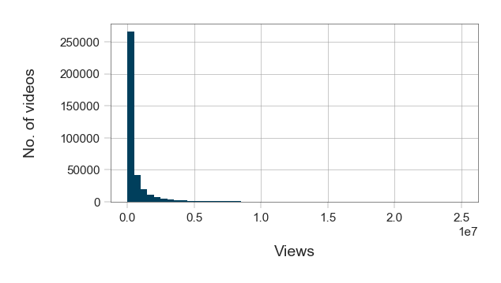

```python
fig, ax = plt.subplots()
_ = sns.distplot(df[df["views"] < 25e6]["views"], kde=False,
                 color=PLOT_COLORS[4], hist_kws={'alpha': 1}, ax=ax)
_ = ax.set(xlabel="Views", ylabel="No. of videos")
```

###### OBSERVATION

```python
print("Percentage of trending videos with 1 million views or less = " +
      str((df[df['views'] <= 1e6]['views'].count() / df['views'].count() * 100).round(2)) + " %")
```

```
Percentage of trending videos with 1 million views or less = 81.59 %
```

# Likes histogram

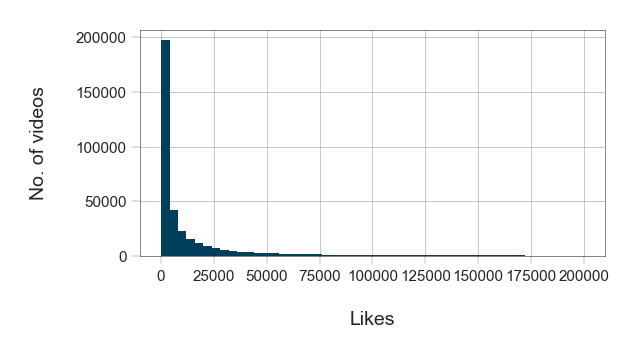

```python
fig, ax = plt.subplots()
_ = sns.distplot(df[df["likes"] <= 2e5]["likes"], kde=False,
                 color=PLOT_COLORS[4], hist_kws={'alpha': 1}, ax=ax)
_ = ax.set(xlabel="Likes", ylabel="No. of videos")
```

```python
print("Percentage of trending videos with 50,000 likes or less = " +
      str((df[df['likes'] <= 5e4]['likes'].count() / df['likes'].count() * 100).round(2)) + " %")
```

```
Percentage of trending videos with 50,000 likes or less = 87.13 %
```

# Dislikes histogram

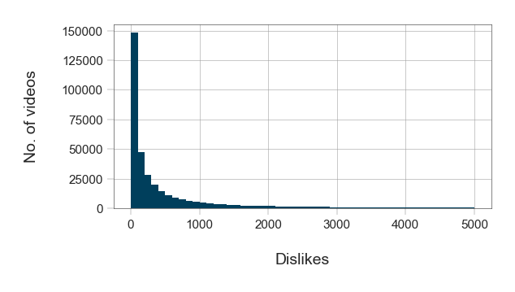

```python
fig, ax = plt.subplots()
_ = sns.distplot(df[df["dislikes"] <= 5e3]["dislikes"], kde=False,
                 color=PLOT_COLORS[4], hist_kws={'alpha': 1}, ax=ax)
_ = ax.set(xlabel="Dislikes", ylabel="No. of videos")
```

```python
print("Percentage of trending videos with 2000 dislikes or less = " +
      str((df[df['dislikes'] <= 2e3]['likes'].count() / df['likes'].count() * 100).round(2)) + " %")
```

```
Percentage of trending videos with 2000 dislikes or less = 87.0 %
```

# Comment Count histogram

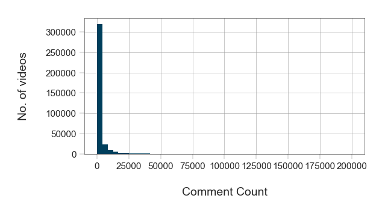

```python
fig, ax = plt.subplots()
_ = sns.distplot(df[df["comment_count"] < 200000]["comment_count"], kde=False, rug=False,
                 color=PLOT_COLORS[4], hist_kws={'alpha': 1},
                 bins=np.linspace(0, 2e5, 49), ax=ax)
_ = ax.set(xlabel="Comment Count", ylabel="No. of videos")
```

```python
print("Percentage of trending videos with 4000 comment count or less = " +
      str((df[df['comment_count'] < 4000]['comment_count'].count() / df['comment_count'].count() * 100).round(2)) + " %")
```

```
Percentage of trending videos with 4000 comment count or less = 84.27 %
```

```python
#All distinct regions
countries = df['region'].unique()
countries
```

```
array(['Great Britan', 'India', 'Russia', 'Mexico', 'Japan',
       'United States', 'France', 'Denmark', 'South Korea', 'Canada'],
      dtype=object)
```

# Comparision of Mean Values of Views,Likes,Dislikes,CommentCount ( Country-Wise)

```python
def MeanCompare(attribute,attribute_name):

    K=[]
    for i in range(0,len(countries)):
        K.append(i)

    plt.plot(K,attribute)
    plt.xlabel('Countries',fontsize=15)
    plt.ylabel(attribute_name,fontsize=15)
    plt.title('Country-Wise ' + attribute_name + ' Mean Values',fontsize=20)
    plt.xticks(K,countries,rotation=30, horizontalalignment='right')
    plt.show()
```

```python
views_mean=[]
likes_mean=[]
dislikes_mean=[]
comments_mean=[]

for i in countries:
    select = df.loc[data['region']==i] #Selects all rows of a particular country
    views_mean.append(select['views'].mean())
    likes_mean.append(select['likes'].mean())
    dislikes_mean.append(select['dislikes'].mean())
    comments_mean.append(select['comment_count'].mean())
```

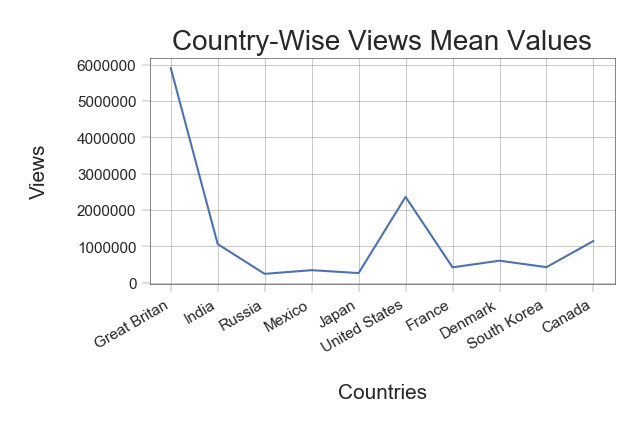

```python
MeanCompare(views_mean,'Views')
```

### OBSERVATION

1.Great Britain has a much higher Average Views value of trending videos, than other countries. (6 million views).

2.Countries with Average Views value <= 1million : Denmark,Mexico,South Korea,Russia,Japan,France.

3.Countries with Average Views value > 1million : Great Britain,Canada,India,US Hence, majority countries have Average Views value of <= 1 million views.

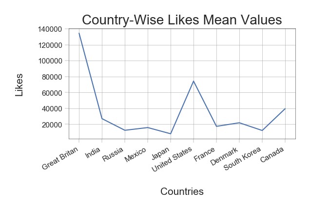

```python
MeanCompare(likes_mean,'Likes')
```

### OBSERVATION

1.Great Britain has a much higher Average Likes value of trending videos than other countries. (>120,000 likes)

2.Countries with Average Likes value <= 50,000 Likes : Canada,Denmark,Mexico,India,South Korea,Russia,Japan,France

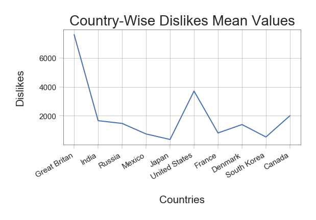

```python
MeanCompare(dislikes_mean,'Dislikes')
```

### OBSERVATION

1.Great Britain has a much higher Average Dislikes value of trending videos than other countries. (>6000 dislikes)

2.Countries with Average Dislikes value <= 2000 Dislikes : Canada,Denmark,Mexico,India,South Korea,Russia,Japan,France

3.Countries with Average Dislikes value >2000 Dislikes : Great Britain,US.

Hence, majority countries have Average Dislikes value of <= 2000 Dislikes.

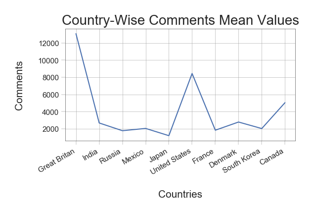

```python
MeanCompare(comments_mean,'Comments')
```

### OBSERVATIONS

1.Great Britain has a much higher Average Comment Count value of trending videos than other countries. (>12,000 comments)

2.Countries with Average Comment Count value <= 4000 Comments : Denmark,Mexico,India,South Korea,Russia,Japan,France

3.Countries with Average Comment Count value > 4000 Comments : Great Britain,Canada,US

Hence, majority countries have Average Comments value of <= 4000 Comments.

# Correlation of Attributes(Globally)

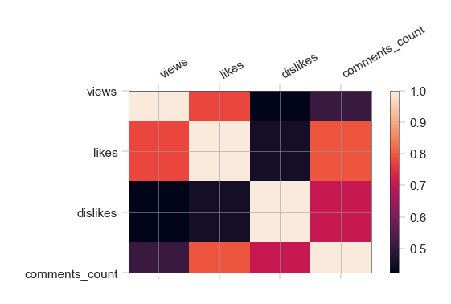

```python
correlations = df.corr()
names = ['views','likes','dislikes','comments_count']
fig = plt.figure()
ax = fig.add_subplot(111)
cax = ax.matshow(correlations)
fig.colorbar(cax)
ticks = np.arange(0,4,1)
ax.set_xticks(ticks)
ax.set_yticks(ticks)
ax.set_xticklabels(names,rotation=30,horizontalalignment='left')
ax.set_yticklabels(names)
plt.show()
```

OBSERVATION

1.There is a strong positive correlation between the number of likes and the number of comments of trending videos: As one of them increases, the other increases, and vice versa.

2.There is a strong positive correlation also between the number of views and the number of likes.

3.There is a slightly weaker correlation between the number of dislikes and the number of comments